# Data Description:

# Ensemble Models

## Importing few Bagging and Boosting Algorithms

```python
from sklearn. ensemble import RandomForestClassifier, BaggingClassifier, AdaBoostClassifier, VotingClassifier
from sklearn.tree import DecisionTreeClassifier
from sklearn.model_selection import cross_val_score
```

## AdaBoost

```python
## Boosting
#Initially, all observations in the dataset are given equal weights.
#A model is built on a subset of data.
#Using this model, predictions are made on the whole dataset.
#Errors are calculated by comparing the predictions and actual values.
#While creating the next model, higher weights are given to the data points which were predicted incorrectly.
#Weights can be determined using the error value. For instance, higher the error more is the weight assigned to the observation.
#This process is repeated until the error function does not change, or the maximum limit of the number of estimators is reached.

adb = AdaBoostClassifier(DecisionTreeClassifier(),n_estimators = 3, learning_rate = 0.001)
adb.fit(X_train,y_train) ## Tries to find the pattern in the data

print("Training score=",adb.score(X_train,y_train))
print("Testing score=",adb.score(X_test,y_test))

accuracies_adaboost= cross_val_score(estimator = adb, X = X_train, y = y_train, cv = 10)
accuracies_adaboost_mean=accuracies_adaboost.mean()
print("Accuracy AdaBoost=",accuracies_adaboost_mean)

accuracies_adaboost_std=accuracies_adaboost.std()
print("Standard Deviation AdaBoost=",accuracies_adaboost_std)
```

```
Training score= 1.0
Testing score= 0.9681509879091713
Accuracy AdaBoost= 0.9305956833821261
Standard Deviation AdaBoost= 0.002491113618181767
```

```python
pred_adb_us=adb.predict(X_test)

from sklearn.metrics import classification_report,confusion_matrix

adb_cm_us = confusion_matrix(y_test,pred_adb_us)
adb_cr_us= classification_report(y_test,pred_adb_us)

print(adb_cm_us)
print(adb_cr_us)

mean_roc_auc_score_adb_us = cross_val_score(estimator = adb, X = X_train, y = y_train, scoring="roc_auc", cv = 10).mean()
std_roc_auc_score_adb_us = cross_val_score(estimator = adb, X = X_train, y = y_train, scoring="roc_auc", cv = 10).std()

print("Mean AUC ROC Score:AdaBoost Upsample=",mean_roc_auc_score_adb_us)
print("Std Dev AUC ROC Score:AdaBoost Upsample=",std_roc_auc_score_adb_us)
```

```
[[11542   427]
 [    5  1590]]
              precision    recall  f1-score   support

           0       1.00      0.96      0.98     11969
           1       0.79      1.00      0.88      1595

   micro avg       0.97      0.97      0.97     13564
   macro avg       0.89      0.98      0.93     13564
weighted avg       0.97      0.97      0.97     13564

Mean AUC ROC Score:AdaBoost Upsample= 0.9307597074052139
Std Dev AUC ROC Score:AdaBoost Upsample= 0.002306863657047914
```

# Gradient Boost Classifier

```python
## Gradient Boost Classifier

from sklearn.ensemble import GradientBoostingClassifier
gbc= GradientBoostingClassifier(learning_rate=0.01,random_state=1)
gbc.fit(X_train, y_train)

gbc_train=gbc.score(X_train,y_train)
print("gbc_train=",gbc_train)

gbc_test=gbc.score(X_test,y_test)
print("gbc_test=",gbc_test)

accuracies_gboost= cross_val_score(estimator = gbc, X = X_train, y = y_train, cv = 10)
accuracies_gboost_mean=accuracies_gboost.mean()
print("Accuracy Gradient Boost=",accuracies_gboost_mean)

accuracies_gboost_std=accuracies_gboost.std()
print("Standard Deviation Gradient Boost=",accuracies_gboost_std)
```

```
gbc_train= 0.674306673823582
gbc_test= 0.6748009436744323
Accuracy Gradient Boost= 0.6737878979409304
Standard Deviation Gradient Boost= 0.0070477941395217635
```

```python
pred_gbc_us=gbc.predict(X_test)

from sklearn.metrics import classification_report,confusion_matrix

gbc_cm_us = confusion_matrix(y_test,pred_gbc_us)
gbc_cr_us= classification_report(y_test,pred_gbc_us)

print(gbc_cm_us)
print(gbc_cr_us)


mean_roc_auc_score_gbc_us = cross_val_score(estimator = gbc, X = X_train, y = y_train, scoring="roc_auc", cv = 10).mean()
std_roc_auc_score_gbc_us = cross_val_score(estimator = gbc, X = X_train, y = y_train, scoring="roc_auc", cv = 10).std()

print("Mean AUC ROC Score:Gradient Boost Classifier Upsample=",mean_roc_auc_score_gbc_us)
print("Std Dev AUC ROC Score:Gradient Boost Classifier=",std_roc_auc_score_gbc_us)
```

```
[[8075 3894]
 [ 517 1078]]
              precision    recall  f1-score   support

           0       0.94      0.67      0.79     11969
           1       0.22      0.68      0.33      1595

   micro avg       0.67      0.67      0.67     13564
   macro avg       0.58      0.68      0.56     13564
weighted avg       0.85      0.67      0.73     13564

Mean AUC ROC Score:Gradient Boost Classifier Upsample= 0.7539550134068727
Std Dev AUC ROC Score:Gradient Boost Classifier= 0.005311255650727212
```

# Meta Bagging Estimator

```python
# Bagging meta estimator
#Random subsets are created from the original dataset (Bootstrapping).
#The subset of the dataset includes all features.
#A user-specified base estimator is fitted on each of these smaller sets.
#Predictions from each model are combined to get the final result.


from sklearn.ensemble import BaggingClassifier
from sklearn import tree

mbc = BaggingClassifier(tree.DecisionTreeClassifier(random_state=1))
mbc.fit(X_train, y_train)

print("mgc_train=",mbc.score(X_train, y_train))
print("mgc_test=",mbc.score(X_test,y_test))

accuracies_Bagging_MEst= cross_val_score(estimator = mbc, X = X_train, y = y_train, cv = 10)
accuracies_Bagging_MEst_Mean=accuracies_Bagging_MEst.mean()

print("Accuracy Bagging=",accuracies_Bagging_MEst_Mean)

accuracies_bagging_MEst_std=accuracies_Bagging_MEst_Mean.std()
print("Standard Deviation Bagging=",accuracies_bagging_MEst_std)
```

```
mgc_train= 0.9988191089640365
mgc_test= 0.9792833972279563
Accuracy Bagging= 0.9579709685914155
Standard Deviation Bagging= 0.0
```

```python
pred_mbc_us=mbc.predict(X_test)

from sklearn.metrics import classification_report,confusion_matrix

mbc_cm_us = confusion_matrix(y_test,pred_mbc_us)
mbc_cr_us= classification_report(y_test,pred_mbc_us)

print(mbc_cm_us)
print(mbc_cr_us)


mean_roc_auc_score_mbc_us = cross_val_score(estimator = mbc, X = X_train, y = y_train, scoring="roc_auc", cv = 10).mean()
std_roc_auc_score_mbc_us = cross_val_score(estimator = mbc, X = X_train, y = y_train, scoring="roc_auc", cv = 10).std()

print("Mean AUC ROC Score:Meta Bagging Classifier Upsample=",mean_roc_auc_score_mbc_us)
print("Std Dev AUC ROC Score:Meta Bagging Classifier Upsample=",std_roc_auc_score_mbc_us)
```

```
[[11698   271]
 [   10  1585]]
              precision    recall  f1-score   support

           0       1.00      0.98      0.99     11969
           1       0.85      0.99      0.92      1595

   micro avg       0.98      0.98      0.98     13564
   macro avg       0.93      0.99      0.95     13564
weighted avg       0.98      0.98      0.98     13564

Mean AUC ROC Score:Meta Bagging Classifier Upsample= 0.9919178620379933
Std Dev AUC ROC Score:Meta Bagging Classifier Upsample= 0.0011621273529923777
```

# Voting Classifier

### SVM Classifier was drop because of very high commutation time

```python
## Bagging on multiple classifiers:
from sklearn.ensemble import VotingClassifier
from sklearn.linear_model import LogisticRegression
from sklearn.svm import SVC
from sklearn.neighbors import KNeighborsClassifier
from sklearn.naive_bayes import GaussianNB
from sklearn.tree import DecisionTreeClassifier
from sklearn.ensemble import RandomForestClassifier

lr = LogisticRegression(solver='liblinear')
#svm=SVC(kernel = 'linear', C=10,gamma=1)
knn=KNeighborsClassifier(n_neighbors = 4, metric = 'minkowski', p = 2)
nb=GaussianNB()
dt=DecisionTreeClassifier(criterion = 'entropy')
rf=RandomForestClassifier(n_estimators = 10, criterion = 'entropy')
#ann_classifier=KerasClassifier(build_fn=buildClassifier_DP,batch_size = 25, epochs = 100)


evc = VotingClassifier( estimators= [('lr',lr),('dt',dt),('knn',knn),('nb',nb),('rf',rf)], voting = 'hard')
#evc = VotingClassifier( estimators= [('lr',lr),('dt',dt),('svm',svm),('knn',knn),('nb',nb),('rf',rf)], voting = 'hard')
evc.fit(X_train,y_train)

print("evc_train=",evc.score(X_train,y_train))
print("evc_test",evc.score(X_test,y_test))



from sklearn.model_selection import cross_val_score

accuracies_EVC= cross_val_score(estimator = evc, X = X_train, y = y_train, cv = 10)
accuracies_EVC_mean=accuracies_EVC.mean()
print("Accuracy EVC=",accuracies_EVC_mean)

accuracies_EVC_std=accuracies_EVC_mean.std()
print("Standard Deviation EVC=",accuracies_EVC_std)
```

```
evc_train= 0.9812488817319736
evc_test 0.9535535240342082
Accuracy EVC= 0.9326535014904499
Standard Deviation EVC= 0.0
```

```python
pred_evc_us=evc.predict(X_test)

from sklearn.metrics import classification_report,confusion_matrix

evc_cm_us = confusion_matrix(y_test,pred_evc_us)
evc_cr_us= classification_report(y_test,pred_evc_us)

print(evc_cm_us)
print(evc_cr_us)
```

```
[[11383   586]
 [   44  1551]]
              precision    recall  f1-score   support

           0       1.00      0.95      0.97     11969
           1       0.73      0.97      0.83      1595

   micro avg       0.95      0.95      0.95     13564
   macro avg       0.86      0.96      0.90     13564
weighted avg       0.96      0.95      0.96     13564
```

# Max Voting

```python
import statistics
model1 = tree.DecisionTreeClassifier()
model2 = KNeighborsClassifier()
model3= LogisticRegression()

model1.fit(X_train,y_train)
model2.fit(X_train,y_train)
model3.fit(X_train,y_train)

pred1=model1.predict(X_test)
pred2=model2.predict(X_test)
pred3=model3.predict(X_test)

final_pred = np.array([])
for i in range(0,len(X_test)):
    final_pred = np.append(final_pred, statistics.mode([pred1[i], pred2[i], pred3[i]]))

#print("maxvoting_test",evc.score(X_test,final_pred))
#print("\n")

# Making the Confusion Matrix
from sklearn.metrics import confusion_matrix,classification_report

cm = confusion_matrix(y_test, final_pred)
print(classification_report(y_test, final_pred))
```

```
              precision    recall  f1-score   support

           0       1.00      0.91      0.95     11969
           1       0.58      0.98      0.73      1595

   micro avg       0.92      0.92      0.92     13564
   macro avg       0.79      0.94      0.84     13564
weighted avg       0.95      0.92      0.92     13564
```

# Decision Tree

```python
## By default, criteria= Gini

from sklearn.tree import DecisionTreeClassifier
classifier = DecisionTreeClassifier()

classifier.fit(X_train,y_train)

predictions = classifier.predict(X_test)


from sklearn.metrics import classification_report,confusion_matrix
print(confusion_matrix(y_test,predictions))
print(classification_report(y_test,predictions))
from sklearn.model_selection import cross_val_score

accuracies_dt= cross_val_score(estimator = classifier, X = X_train, y = y_train, cv = 10)
accuracies_dt_mean=accuracies_dt.mean()
print("Mean Accuracy:Decision Tree=",accuracies_dt_mean)

accuracies_dt_std=accuracies_dt.std()
print("Standard Deviation - Accuracy:Decision Tree=",accuracies_dt_std)

mean_roc_auc_score = cross_val_score(estimator = classifier, X = X_train, y = y_train, scoring="roc_auc", cv = 7).mean()
std_roc_auc_score = cross_val_score(estimator = classifier, X = X_train, y = y_train, scoring="roc_auc", cv = 7).std()

print("Mean AUC ROC Score:",mean_roc_auc_score)
print("Std Dev AUC ROC Score:",std_roc_auc_score)
```

```
[[11531   438]
 [    5  1590]]
              precision    recall  f1-score   support

           0       1.00      0.96      0.98     11969
           1       0.78      1.00      0.88      1595

   micro avg       0.97      0.97      0.97     13564
   macro avg       0.89      0.98      0.93     13564
weighted avg       0.97      0.97      0.97     13564

Mean Accuracy:Decision Tree= 0.9306493282374344
Standard Deviation - Accuracy:Decision Tree= 0.0028958080402008645
Mean AUC ROC Score: 0.9282208328988355
Std Dev AUC ROC Score: 0.003109894413122932
```

```python
## Using Entropy

classifier=DecisionTreeClassifier(criterion='entropy')
classifier.fit(X_train, y_train)
#preds_entropy = model_entropy.predict(X_test)

accuracies_dt= cross_val_score(estimator = classifier, X = X_train, y = y_train, cv = 10)
accuracies_dt_mean=accuracies_dt.mean()
print("Mean Accuracy:Decision Tree=",accuracies_dt_mean)

accuracies_dt_std=accuracies_dt.std()
print("Standard Deviation - Accuracy:Decision Tree=",accuracies_dt_std)

mean_roc_auc_score = cross_val_score(estimator = classifier, X = X_train, y = y_train, scoring="roc_auc", cv = 7).mean()
std_roc_auc_score = cross_val_score(estimator = classifier, X = X_train, y = y_train, scoring="roc_auc", cv = 7).std()

print("Mean AUC ROC Score:",mean_roc_auc_score)
print("Std Dev AUC ROC Score:",std_roc_auc_score)
```

```
Mean Accuracy:Decision Tree= 0.9330112704221826
Standard Deviation - Accuracy:Decision Tree= 0.002549465720209627
Mean AUC ROC Score: 0.9260783314877215
Std Dev AUC ROC Score: 0.0031201868528137927
```

```python
## Using pruning

classifier = DecisionTreeClassifier(criterion = "gini", random_state = 100,max_depth=3, min_samples_leaf=5)
classifier.fit(X_train, y_train)
#preds_entropy = model_entropy.predict(X_test)

accuracies_dt= cross_val_score(estimator = classifier, X = X_train, y = y_train, cv = 10)
accuracies_dt_mean=accuracies_dt.mean()
print("Mean Accuracy:Decision Tree=",accuracies_dt_mean)

accuracies_dt_std=accuracies_dt.std()
print("Standard Deviation - Accuracy:Decision Tree=",accuracies_dt_std)

mean_roc_auc_score = cross_val_score(estimator = classifier, X = X_train, y = y_train, scoring="roc_auc", cv = 7).mean()
std_roc_auc_score = cross_val_score(estimator = classifier, X = X_train, y = y_train, scoring="roc_auc", cv = 7).std()

print("Mean AUC ROC Score:",mean_roc_auc_score)
print("Std Dev AUC ROC Score:",std_roc_auc_score)
```

```
Mean Accuracy:Decision Tree= 0.6574879491305452
Standard Deviation - Accuracy:Decision Tree= 0.005669921859973193
Mean AUC ROC Score: 0.7065287061681559
Std Dev AUC ROC Score: 0.004443852631231427
```

#### Optimal Hyperparameters/ Tuning of Decision Tree parameters

```python
from sklearn.model_selection import GridSearchCV
from sklearn.tree import DecisionTreeClassifier

#making the instance
model= DecisionTreeClassifier(random_state=123)
#Hyper Parameters Set
params = {
          'criterion':['gini','entropy'],
          'max_features': ['auto', 'sqrt', 'log2'],
          'min_samples_split': [2,3,4,5,6,7,8,9,10,11,12,13,14,15],
          'min_samples_leaf':[1,2,3,4,5,6,7,8,9,10,11],
          'random_state':[123],
          'max_depth':[1,2,3,4,5,6]
        }
#Making models with hyper parameters sets
classifier = GridSearchCV(model, param_grid=params, n_jobs=-1)

#Learning
classifier.fit(X_train,y_train)
#The best hyper parameters set

print("Best Hyper Parameters:",classifier.best_params_)


#Prediction
from sklearn.metrics import classification_report,confusion_matrix


predictions=classifier.predict(X_test)
print(confusion_matrix(y_test,predictions))
print(classification_report(y_test,predictions))

from sklearn.model_selection import cross_val_score

accuracies_dt= cross_val_score(estimator = classifier, X = X_train, y = y_train, cv = 10)
accuracies_dt_mean=accuracies_dt.mean()
print("Mean Accuracy:Decision Tree=",accuracies_dt_mean)

accuracies_dt_std=accuracies_dt.std()
print("Standard Deviation - Accuracy:Decision Tree=",accuracies_dt_std)

mean_roc_auc_score = cross_val_score(estimator = classifier, X = X_train, y = y_train, scoring="roc_auc", cv = 7).mean()
std_roc_auc_score = cross_val_score(estimator = classifier, X = X_train, y = y_train, scoring="roc_auc", cv = 7).std()

print("Mean AUC ROC Score:",mean_roc_auc_score)
print("Std Dev AUC ROC Score:",std_roc_auc_score)
```

```
Best Hyper Parameters: {'criterion': 'entropy', 'max_depth': 6, 'max_features': 'auto', 'min_samples_leaf': 1, 'min_samples_split': 15, 'random_state': 123}
[[9867 2102]
 [ 726  869]]
              precision    recall  f1-score   support

           0       0.93      0.82      0.87     11969
           1       0.29      0.54      0.38      1595

   micro avg       0.79      0.79      0.79     13564
   macro avg       0.61      0.68      0.63     13564
weighted avg       0.86      0.79      0.82     13564
```

```
Mean Accuracy:Decision Tree= 0.6823575904061374
Standard Deviation - Accuracy:Decision Tree= 0.005834889706660452
```

# Random Forest with parameter tuning

```python
from sklearn.ensemble import RandomForestClassifier
classifier = RandomForestClassifier(n_estimators=25) ## Hyperparameter
classifier.fit(X_train,y_train)
predictions = classifier.predict(X_test)


from sklearn.metrics import classification_report,confusion_matrix
print(confusion_matrix(y_test,predictions))
print(classification_report(y_test,predictions))

from sklearn.model_selection import cross_val_score

accuracies_logistic= cross_val_score(estimator = classifier, X = X_train, y = y_train, cv = 10)
accuracies_logistic_mean=accuracies_logistic.mean()
print("Mean Accuracy:Random Forest=",accuracies_logistic_mean)

accuracies_logistic_std=accuracies_logistic.std()
print("Standard Deviation:Random Forest=",accuracies_logistic_std)


## Hyper Parameter Tuning
print('Parameters currently in use:\n')
print(classifier.get_params())
print("\n")

# Number of trees in random forest
n_estimators = [int(x) for x in np.linspace(start = 50, stop = 200, num = 5)] ## play with start and stop

# Number of features to consider at every split
max_features = ['auto', 'sqrt']

# Maximum number of levels in tree
max_depth = [int(x) for x in np.linspace(10, 20, num = 5)] ## change 10,20 and 2
max_depth.append(None)

# Minimum number of samples required to split a node
min_samples_split = [2, 5, 10,15]

# Minimum number of samples required at each leaf node
min_samples_leaf = [1, 2, 4,10]

# Method of selecting samples for training each tree
bootstrap = [True, False]

# Create the random grid
random_grid = {'n_estimators': n_estimators,
               'max_features': max_features,
               'max_depth': max_depth,
               'min_samples_split': min_samples_split,
               'min_samples_leaf': min_samples_leaf,
               'bootstrap': bootstrap}

print(random_grid)

from sklearn.model_selection import RandomizedSearchCV

rf_random = RandomizedSearchCV(estimator = classifier, param_distributions = random_grid, n_iter = 100, cv = 3,
                               verbose=2, random_state=42, n_jobs = -1)
# Fit the random search model
rf_random.fit(X_train,y_train)
print("Best Parameters are:",rf_random.best_params_)
```

```
[[11748   221]
 [    7  1588]]
              precision    recall  f1-score   support

           0       1.00      0.98      0.99     11969
           1       0.88      1.00      0.93      1595

   micro avg       0.98      0.98      0.98     13564
   macro avg       0.94      0.99      0.96     13564
weighted avg       0.99      0.98      0.98     13564

Mean Accuracy:Random Forest= 0.9652172751717171
Standard Deviation:Random Forest= 0.002906657853248225
Parameters currently in use:

{'bootstrap': True, 'class_weight': None, 'criterion': 'gini', 'max_depth': None, 'max_features': 'auto', 'max_leaf_nodes': None, 'min_impurity_decrease': 0.0, 'min_impurity_split': None, 'min_samples_leaf': 1, 'min_samples_split': 2, 'min_weight_fraction_leaf': 0.0, 'n_estimators': 25, 'n_jobs': No…


{'n_estimators': [50, 87, 125, 162, 200], 'max_features': ['auto', 'sqrt'], 'max_depth': [10, 12, 15, 17, 20, None], 'min_samples_split': [2, 5, 10, 15], 'min_samples_leaf': [1, 2, 4, 10], 'bootstrap': [True, False]}
Fitting 3 folds for each of 100 candidates, totalling 300 fits
```

```
[Parallel(n_jobs=-1)]: Using backend LokyBackend with 4 concurrent workers.
[Parallel(n_jobs=-1)]: Done  33 tasks      | elapsed:  2.4min
[Parallel(n_jobs=-1)]: Done 154 tasks      | elapsed:  8.8min
[Parallel(n_jobs=-1)]: Done 300 out of 300 | elapsed: 19.1min finished
```

```
Best Parameters are: {'n_estimators': 87, 'min_samples_split': 2, 'min_samples_leaf': 1, 'max_features': 'sqrt', 'max_depth': None, 'bootstrap': True}
```

```python
best_random = rf_random.best_estimator_
best_random.fit(X_train,y_train)

predictions = best_random.predict(X_test)


from sklearn.metrics import classification_report,confusion_matrix
print(confusion_matrix(y_test,predictions))
print(classification_report(y_test,predictions))

from sklearn.model_selection import cross_val_score

accuracies_rf= cross_val_score(estimator = best_random, X = X_train, y = y_train, cv = 10)
accuracies_rf_mean=accuracies_rf.mean()
print("Mean Accuracy:Random Forest=",accuracies_logistic_mean)

accuracies_rf_std=accuracies_logistic.std()
print("Standard Deviation:Random Forest=",accuracies_rf_std)
```

```
[[11755   214]
 [    7  1588]]
              precision    recall  f1-score   support

           0       1.00      0.98      0.99     11969
           1       0.88      1.00      0.93      1595

   micro avg       0.98      0.98      0.98     13564
   macro avg       0.94      0.99      0.96     13564
weighted avg       0.99      0.98      0.98     13564

Mean Accuracy:Random Forest= 0.9652172751717171
Standard Deviation:Random Forest= 0.002906657853248225
```

```python
mean_roc_auc_score = cross_val_score(estimator = best_random, X = X_train, y = y_train, scoring="roc_auc", cv = 7).mean()
std_roc_auc_score = cross_val_score(estimator =best_random, X = X_train, y = y_train, scoring="roc_auc", cv = 7).std()

print("Mean AUC ROC Score: ",mean_roc_auc_score)
print("Std Dev AUC ROC Score:",std_roc_auc_score)
```

```
Mean AUC ROC Score:  0.9968828726400101
Std Dev AUC ROC Score: 0.0006967314930109065
```

# Light GBM

```python
import lightgbm as lgb
d_train = lgb.Dataset(X_train, label=y_train)
params = {}
params['learning_rate'] = 0.003
params['boosting_type'] = 'gbdt' ## gradient boosting
params['objective'] = 'binary' ## since its a classification problem
params['metric'] = 'binary_logloss'
params['sub_feature'] = 0.5
params['num_leaves'] = 10
params['min_data'] = 50
params['max_depth'] = 10
clf = lgb.train(params, d_train, 100)


#Prediction
y_pred=clf.predict(X_test)

#convert into binary values
for i in range(0,13564): ## 10000 indicates the number of rows in the dataset
    if y_pred[i]>=0.5:       # setting threshold to .5
       y_pred[i]=1
    else:
       y_pred[i]=0

from sklearn.metrics import confusion_matrix,classification_report
cm = confusion_matrix(y_test, y_pred)
print(cm)
print(classification_report(y_test, y_pred))
```

```
[[9313 2656]
 [ 544 1051]]
              precision    recall  f1-score   support

           0       0.94      0.78      0.85     11969
           1       0.28      0.66      0.40      1595

   micro avg       0.76      0.76      0.76     13564
   macro avg       0.61      0.72      0.62     13564
weighted avg       0.87      0.76      0.80     13564
```

# XgBoost

```python
from xgboost import XGBClassifier
classifier = XGBClassifier()
classifier.fit(X_train, y_train)

# Making the Confusion Matrix

from sklearn.metrics import confusion_matrix,classification_report
cm = confusion_matrix(y_test, y_pred)
print(cm)
print(classification_report(y_test, y_pred))

from sklearn.model_selection import cross_val_score
accuracies = cross_val_score(estimator = classifier, X = X_train, y = y_train, cv = 10)

mean_score = cross_val_score(estimator = classifier, X = X_train, y = y_train, scoring="roc_auc", cv = 7).mean()
std_score = cross_val_score(estimator = classifier, X = X_train, y = y_train, scoring="roc_auc", cv = 7).std()


print ("Accuracy=",mean_score)
print("Standard Deviation",std_score)

mean_roc_auc_score = cross_val_score(estimator = classifier, X = X_train, y = y_train, scoring="roc_auc", cv = 7).mean()
std_roc_auc_score = cross_val_score(estimator = classifier, X = X_train, y = y_train, scoring="roc_auc", cv = 7).std()

print("Mean AUC ROC Score:",mean_roc_auc_score)
print("Std Dev AUC ROC Score:",std_roc_auc_score)
```

```
[[9313 2656]
 [ 544 1051]]
              precision    recall  f1-score   support

           0       0.94      0.78      0.85     11969
           1       0.28      0.66      0.40      1595

   micro avg       0.76      0.76      0.76     13564
   macro avg       0.61      0.72      0.62     13564
weighted avg       0.87      0.76      0.80     13564

Accuracy= 0.804907715418236
Standard Deviation 0.00497248943662339
Mean AUC ROC Score: 0.804907715418236
Std Dev AUC ROC Score: 0.00497248943662339
```

# Cat Boost

```python
from catboost import CatBoostClassifier
categorical_features_indices = np.where(X.dtypes == np.object)[0]
### In Case of Regression
##from catboost import CatBoostRegressor
##model=CatBoostRegressor(iterations=50, depth=3, learning_rate=0.1, loss_function='RMSE')
##model.fit(X_train, y_train,cat_features=categorical_features_indices,eval_set=(X_validation, y_validation),plot=True)

cbc=CatBoostClassifier(iterations=100, depth=3, learning_rate=0.1, loss_function='Logloss')
cbc.fit(X_train, y_train,cat_features=categorical_features_indices,eval_set=(X_test, y_test),plot=True)

y_pred=cbc.predict(X_test)

from sklearn.metrics import confusion_matrix,classification_report
cm = confusion_matrix(y_test, y_pred)
print(cm)
print(classification_report(y_test, y_pred))
```

[output not shown]

[output cut: 59 more lines]

```
99:	learn: 0.5400572	test: 0.5352072	best: 0.5352072 (99)	total: 3.68s	remaining: 0us

bestTest = 0.5352071547
bestIteration = 99

[[9881 2088]
 [ 551 1044]]
              precision    recall  f1-score   support

           0       0.95      0.83      0.88     11969
           1       0.33      0.65      0.44      1595

   micro avg       0.81      0.81      0.81     13564
   macro avg       0.64      0.74      0.66     13564
weighted avg       0.87      0.81      0.83     13564
```

```python
from sklearn.model_selection import cross_val_score

accuracies_cbc= cross_val_score(estimator = cbc, X = X_train, y = y_train, cv = 10)
accuracies_cbc_mean=accuracies_cbc.mean()
print("Accuracy Cat Boost Classifier=",accuracies_EVC_mean)

accuracies_cbc_std=accuracies_cbc_mean.std()
print("Standard Deviation Cat Boost Classifier=",accuracies_EVC_std)

mean_roc_auc_score = cross_val_score(estimator = cbc, X = X_train, y = y_train, scoring="roc_auc", cv = 7).mean()
std_roc_auc_score = cross_val_score(estimator = cbc, X = X_train, y = y_train, scoring="roc_auc", cv = 7).std()

print("Mean AUC ROC Score:",mean_roc_auc_score)
print("Std Dev AUC ROC Score:",std_roc_auc_score)
```

[output not shown]

[output cut: 2349 more lines]

[output not shown]

## Stacking

```python
from xgboost import XGBClassifier
from sklearn.model_selection import train_test_split
xgb = XGBClassifier()
xgb.fit(X_train,y_train)
pred_val_xgb=xgb.predict(X_train)
test_pred_xgb=xgb.predict(X_test)




best_random.fit(X_train,y_train) ## Best Hyperparameters of random Forest found above
pred_val_rf=best_random.predict(X_train)
test_pred_rf=best_random.predict(X_test)


lr = LogisticRegression()
stacked_predictions=np.column_stack((pred_val_rf,pred_val_xgb))

#stacked_predictions[0:10]
stacked_test_predictions=np.column_stack((test_pred_rf,test_pred_xgb))
#stacked_test_predictions[0:10]

## Building Meta Model
lr.fit(stacked_predictions,y_train)

y_pred=lr.predict(stacked_test_predictions)
y_pred
```

```
array([0, 1, 0, ..., 0, 0, 0])
```

```python
from sklearn.metrics import confusion_matrix,classification_report
cm = confusion_matrix(y_test, y_pred)
print(cm)
print(classification_report(y_test, y_pred))

accuracies_lr= cross_val_score(estimator = lr, X = stacked_predictions, y = y_train, cv = 10)
accuracies_lr_mean=accuracies_lr.mean()
print("Accuracy Stacking=",accuracies_lr_mean)

accuracies_lr_std=accuracies_lr_mean.std()
print("Standard Deviation lr=",accuracies_lr_std)
```

```
[[11757   212]
 [    5  1590]]
              precision    recall  f1-score   support

           0       1.00      0.98      0.99     11969
           1       0.88      1.00      0.94      1595

   micro avg       0.98      0.98      0.98     13564
   macro avg       0.94      0.99      0.96     13564
weighted avg       0.99      0.98      0.98     13564
```

[output not shown]

# Blending

```python
## Mix independent variables and stacked outputs

from sklearn.model_selection import train_test_split


model1 = rf_random.best_estimator_ ## Best hyperparameters of Random Forest
model1.fit(X_train, y_train)
val_pred1=model1.predict(X_train)
test_pred1=model1.predict(X_test)


model2 = XGBClassifier()
model2.fit(X_train,y_train)
val_pred2=model2.predict(X_train)
test_pred2=model2.predict(X_test)


stacked_predictions=np.column_stack((X_train,val_pred1,val_pred2))
stacked_test_predictions=np.column_stack((X_test,test_pred1,test_pred2))

stacked_predictions=pd.DataFrame(stacked_predictions)
stacked_test_predictions=pd.DataFrame(stacked_test_predictions)

## Building Meta Model
lr = LogisticRegression()
lr.fit(stacked_predictions,y_train)

y_pred=lr.predict(stacked_test_predictions)
y_pred

from sklearn.metrics import confusion_matrix,classification_report
cm = confusion_matrix(y_test, y_pred)
print(cm)
print(classification_report(y_test, y_pred))
```

```
[[11762   207]
 [    6  1589]]
              precision    recall  f1-score   support

           0       1.00      0.98      0.99     11969
           1       0.88      1.00      0.94      1595

   micro avg       0.98      0.98      0.98     13564
   macro avg       0.94      0.99      0.96     13564
weighted avg       0.99      0.98      0.98     13564
```

## Conclusion

### Technical Summary

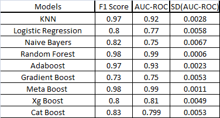

Ensemble means grouping. When you group models or make model learn from previous mistake. Then it becomes powerful. This what makes it different from standard classic models (like NB, LR, KNN,SVM)

Out of all Ensemble Technique, Random Forest worked best with 98% F1 Score, 99% AUC-ROC score and have Least Standard Deviation of 0.0006

### Exceutive Summary

Key outcomes of the analysis are the recommendations for future Bank Term Deposite marketing campaigns:

- The customer's account balance has a huge influence on the campaign's outcome. People with account balance above 1500 euro are more likely to subscribe for term deposit, so future address those customers.
- The customer's age affects campaign outcome as well. Future campains should concentrate on customers from age categories below 31 years old and above 50 years old.
- Number of contacts with the customer during the campaign is also very important. The number of contacts with the customer shouldn't exceed 3
- In future, Client who have default should not be targetted as they are having low chances of going for term deposit.
- Management, Technician and blue collar job cliets are going for term deposit.
- Clients having housing loan and Personal Loans have less chances to go for term deposit.
- If Client is contacted within approx 160 days. his chances to go for term deposit is more
- No Relation between number of times called and term deposits. Regular or frequent number of call does not matter. What matter is kind of remider call as seen in pday relation.
- Last campaign success or failure, does not improve or reduce chances of current campaign term deposits chances.